# Introduction to Game Theory

Lecture 10

Div Bhagia

# Introduction

## Why Game Theory?

So far, we’ve mostly modeled agents as making decisions against an anonymous market: a consumer takes prices as given, a competitive firm takes the market price as given. Nobody’s individual action affects the environment that others face.

**Game theory** is the toolkit for situations where that assumption fails, where the payoff to your action depends on what others do, and they know the same about you.

- Two firms setting prices in a duopoly
- A worker deciding how hard to bargain with an employer
- Countries choosing whether to honor a trade agreement
- A central bank setting policy while private actors anticipate it

## What Makes a Game?

Every game has three ingredients:

1. **Players**: who is making decisions
2. **Strategies**: what each player can do
3. **Payoffs**: what each player gets as a function of the strategies chosen

We’ll also need to specify the **information structure** (who knows what when) and the **timing** (who moves when).

A game is fully specified once you know all of these.

## Two Representations

Games come in two standard forms:

- **Normal (strategic) form:** a payoff matrix listing strategies and payoffs. Best for **simultaneous-move** games.
- **Extensive form:** a game tree showing the order of moves and information sets. Best for **sequential-move** games.

Both representations can describe the same game. The choice is about which aspect, strategies or timing, you want to emphasize.

# Normal Form Games

## The Prisoner’s Dilemma

Two prisoners are separated into individual rooms and cannot communicate with each other. Each has two options: **Cooperate** (stay silent) or **Defect** (testify). The payoffs in years they will have to serve are:

|  | **B Cooperates** | **B Defects** |
| --- | --- | --- |
| **A Cooperates** | (-1, -1) | (-3, 0) |
| **A Defects** | (0, -3) | (-2, -2) |

Each player does better by defecting regardless of what the other does:

- If B cooperates: A gets 0 years by defecting vs. 1 year by cooperating
- If B defects: A gets 2 years by defecting vs. 3 years by cooperating

## Dominant Strategies

A strategy is **strictly dominant** for a player if it yields a strictly higher payoff than any alternative, regardless of what opponents do.

In the Prisoner’s Dilemma, **Defect** is strictly dominant for both players. So the prediction is (Defect, Defect), giving both players 2 years each, even though (Cooperate, Cooperate) would give them 1 year each.

This is the central puzzle: individually rational behavior leads to a collectively bad outcome.

The Prisoner’s Dilemma shows up everywhere: arms races, price wars, overfishing, tax evasion, doping in sports.

## Nash Equilibrium

Not all games have dominant strategies. We need a more general solution concept.

**Nash equilibrium** (Nash, 1950): a profile of strategies $(s_1^*, \dots, s_n^*)$ such that each player’s strategy is a **best response** to the others’. No player has a profitable unilateral deviation.

$$u_i(s_i^*, s_{-i}^*) \geq u_i(s_i, s_{-i}^*) \quad \text{for all } s_i, \text{ for all } i$$

Interpretation: a Nash equilibrium is a “no regrets” profile. Given what everyone else is doing, no one wishes they had chosen differently.

## Finding Nash Equilibria

**To find Nash equilibria in a normal-form game:**

1. For each player, fix the opponent’s strategy and find the best response
2. Underline or circle the payoffs corresponding to those best responses
3. A Nash equilibrium is any cell where **both players are playing best responses**

In the Prisoner’s Dilemma, (Defect, Defect) is the unique Nash equilibrium: both cells where the other defects have Defect underlined, and both cells where the other cooperates also have Defect underlined.

## Example: Coordination Game

Two friends want to meet but can’t communicate. Each can go to a **Cafe** or a **Bar**.

|  | **B: Cafe** | **B: Bar** |
| --- | --- | --- |
| **A: Cafe** | (2, 2) | (0, 0) |
| **A: Bar** | (0, 0) | (1, 1) |

Two pure-strategy Nash equilibria: (Cafe, Cafe) and (Bar, Bar).

The game has **multiple equilibria**, raising the question of how players coordinate on one, and possibly whether some equilibria are more “focal” than others.

## Example: Battle of the Sexes

Same structure, but the players prefer different outcomes. A prefers **Opera**, B prefers **Football**, but both prefer being together.

|  | **B: Opera** | **B: Football** |
| --- | --- | --- |
| **A: Opera** | (2, 1) | (0, 0) |
| **A: Football** | (0, 0) | (1, 2) |

Two pure-strategy Nash equilibria: (Opera, Opera) and (Football, Football). Coordination is good, but there’s **conflict** about which equilibrium to land on.

## Example: Matching Pennies

A zero-sum game. Player A wants the pennies to **match**, Player B wants them to **differ**.

|  | **B: Heads** | **B: Tails** |
| --- | --- | --- |
| **A: Heads** | (1, −1) | (−1, 1) |
| **A: Tails** | (−1, 1) | (1, −1) |

**No pure-strategy Nash equilibrium**. For any pure profile, one player wants to switch.

We need **mixed strategies**.

## Mixed Strategies

A **mixed strategy** is a probability distribution over pure strategies.

A mixed-strategy Nash equilibrium is a profile of randomizations such that each player is **indifferent** between the pure strategies in the support of their mix, given the opponents’ mix.

**Why indifference?** If a player were strictly better off playing one pure strategy, they would play it with probability 1, not mix. Mixing is only rational when you are indifferent.

## Matching Pennies: Solving for the Mix

Let $p$ = probability A plays Heads, $q$ = probability B plays Heads.

A is indifferent between Heads and Tails when B makes both equally attractive:

$$q \cdot 1 + (1 - q)(-1) = q(-1) + (1 - q)(1)$$

$$2q - 1 = 1 - 2q \implies q = 1/2$$

By symmetry, $p = 1/2$. The unique Nash equilibrium is $(p, q) = (1/2, 1/2)$: each player randomizes 50-50.

Expected payoff: 0 for each player. Exactly what you’d guess by symmetry.

## Existence

**Nash’s theorem (1950):** Every finite game (finitely many players, finitely many pure strategies) has at least one Nash equilibrium, possibly in mixed strategies.

This is reassuring: we can always find *some* equilibrium. But the theorem doesn’t tell us which one is selected in games with multiple equilibria, or whether players will actually play it.

# Sequential Games

## Extensive Form

So far, our games have been **simultaneous**. But many real situations are **sequential**: one player moves first, and the second responds after observing the first move.

The extensive form uses a **game tree**:

- Nodes represent decision points (who moves)
- Branches represent actions
- Payoffs sit at the end of each path
- Information sets capture what a player knows when deciding

## Entry Game

An entrant (E) decides whether to **Enter** or **Stay Out** of a market. If E enters, the incumbent (I) decides to **Fight** or **Accommodate**.

| Path | Payoffs (E, I) |
| --- | --- |
| Stay Out | (0, 10) |
| Enter, Accommodate | (2, 5) |
| Enter, Fight | (−3, 0) |

What happens? It depends on what E believes I will do if entry occurs.

## Extensive Form for Entry Game

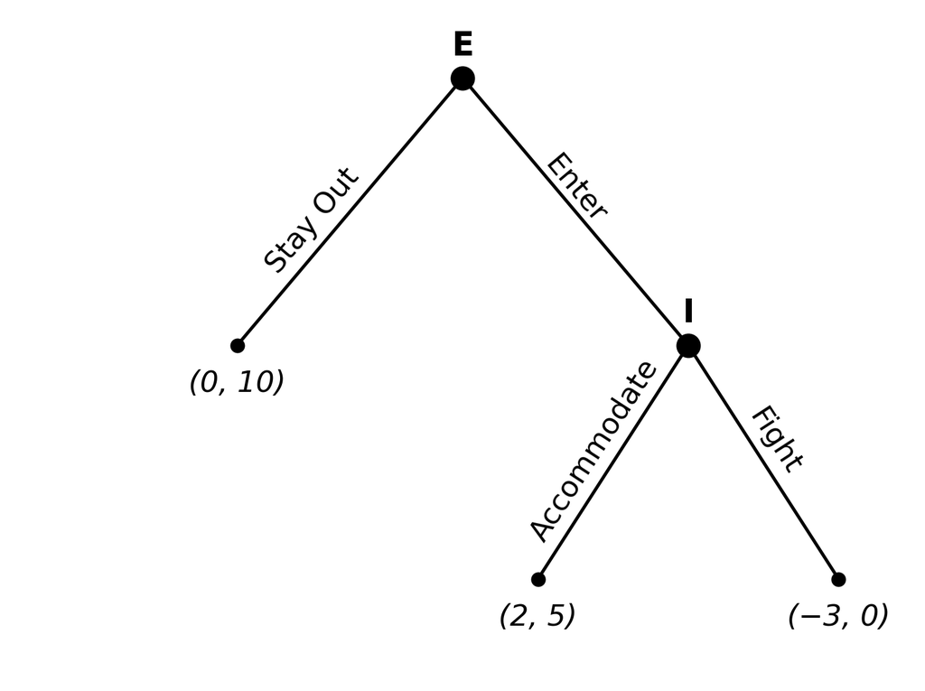

## Backward Induction

Solve **from the end** of the tree back to the beginning.

**Step 1:** If E enters, what does I do? Accommodate (5) beats Fight (0). So I accommodates.

**Step 2:** Given that I will accommodate, what does E do? Enter (2) beats Stay Out (0). So E enters.

**Prediction:** (Enter, Accommodate), payoffs (2, 5).

## Non-Credible Threats

In the entry game, the normal form actually has *two* Nash equilibria: (Enter, Accommodate) and (Stay Out, Fight).

At (Stay Out, Fight), neither player wants to deviate: given that E stays out, I’s strategy of “Fight if entry occurs” is never tested; and given I’s threat to fight, E prefers to stay out.

But the Fight threat is **not credible**: if entry actually occurred, I would not carry it out. Backward induction rules out such non-credible threats.

## Subgame Perfect Equilibrium

**Subgame perfect equilibrium (SPE):** a strategy profile that induces a Nash equilibrium in *every* subgame, not just the whole game.

In finite games of perfect information, the SPE is exactly what **backward induction** gives you. It rules out Nash equilibria that rely on non-credible threats off the equilibrium path.

In the entry game, (Enter, Accommodate) is the unique SPE; (Stay Out, Fight) is Nash but not subgame perfect.

## Commitment and Credibility

Schelling (1960): sometimes you are better off **limiting your own options**. A credible commitment device can change the equilibrium.

- A firm that **builds excess capacity** makes “Fight” credible and can deter entry
- A country that **publicly burns bridges** commits to not retreating
- A central bank with an **inflation targeting mandate** commits to tight policy

Commitment is valuable not despite restricting your future choices but *because* it does.

# Repeated Games

## Repeated Prisoner’s Dilemma

In the one-shot Prisoner’s Dilemma, the only Nash equilibrium is (Defect, Defect). What happens if the same game is played repeatedly?

**Finitely repeated:** backward induction still unravels cooperation. In the last round, both defect. Knowing that, they defect in the second-to-last round. And so on. Defection in every period is the unique SPE.

**Infinitely repeated (or unknown horizon):** cooperation can be sustained as an equilibrium if players are patient enough, using strategies that punish defection (e.g., **tit-for-tat** or **grim trigger**).

## The Folk Theorem (Sketch)

In an infinitely repeated game with a sufficiently patient discount factor, essentially *any* individually rational payoff can be supported as a subgame perfect equilibrium.

**Intuition:** if defection today triggers enough future punishment, players prefer to cooperate.

The flip side: repeated interaction gives us cooperation, but at the cost of a huge **multiplicity of equilibria**. Predicting what will actually happen is hard.